# Introduction to bfastSpatial

Loïc Dutrieux, Ben DeVries and Jan Verbesselt

# Introduction to bfastSpatial

*Loïc Dutrieux, Ben DeVries and Jan Verbesselt*

## Preamble

The `bfastSpatial` package provides utilities to performs change detection analysis (see DeVries et al. 2015; Dutrieux et al. 2015; J. Verbesselt et al. 2010; J. Verbesselt, Zeileis, and Herold 2012) on time-series of spatial gridded data, such as time-series of remote sensing images (Landsat, MODIS and the likes). The tools provided by `bfastSpatial` allows a user to perform all the steps of the change detection workflow, from pre-processing raw surface reflectance Landsat data, inventorying and preparing them for analysis to the production and formatting of change detection results. The present document aims at providing guidance to the users of `bfastSpatial` by detailing every steps of the process.

## Set up your system

### Windows

There are no specific system requirements for Windows, besides having (a recent version of) R installed; installing the `bfastSpatial` package will automatically install the required dependencies.

### Linux & Mac

Some pre-processing functions require the `rgdal` package, which is a binding between the gdal library and R. For `rgdal` to work on Linux and Mac systems, gdal should be installed and properly set-up. For that, please refer to the web page of the [gdal project](http://www.gdal.org/) as well as [rgdal](http://cran.r-project.org/web/packages/rgdal/index.html).

### Installing bfastSpatial

The package can be installed directly from github using devtools, provided you have git already installed on your system:

```r
library(devtools)
install_github('loicdtx/bfastSpatial')
# load the package
library(bfastSpatial)
```

## Downloading Landsat data from Earth Explorer/espa

Working with Landsat time-series often involves downloading large amounts of data. The full Landsat archive for one path/row may very well exceed 500 scenes in some parts of the world. The most common way to access the data is via the [Earth Explorer](http://earthexplorer.usgs.gov/) platform. You need to have an account before being able to request data to be pre-processed.

### Placing your order

USGS is planning to support the delivery of data in different formats (HDF, GeoTiff, binary). GeoTiff is a common and easy to handle format of raster data and should be your preferred choice if you are working in Windows. A convenient way of placing an order at the moment is via [espa](http://espa.cr.usgs.gov/) (your username/password are your USGS credential, which you should already have requested to place your order on EarthExplorer). Once you have entered your credentials, you may use the interface to upload the list of scenes you want to have pre-processed, select the layers of interest and place your order. A scene list is a simple text file with a scene ID (eg: LT52302701999134) on each line.

### Downloading the data

Once you receive the e-mail from ESPA notifying you that your order has been pre-processed, you will be able to proceed to the download of the data. Because the amount of scenes is usually large, the use of a download manager is highly recommended. Two options:

- The Bulk Download Application
- The DownloadThemAll plugin of the firefox browser

## Data pre-processing

The `bfastSpatial` package includes utilities to pre-process Landsat surface reflectance data and prepare them for subsequent analysis with the change detection functions such as `bfmSpatial`. Pre-processing chains for two categories of data are available. The following paragraphs describe the pre-processing steps for Landsat data and for MODIS data.

### Landsat pre-processing

#### List of functions

The landsat pre-processing category contains the following functions.

- `processLandsat()`: The base function that brings a single landsat scene from its archive to a vegetation index raster layer, cropped to a certain extent and with clouds filtered out.
- `processLandsatBatch()`: The batch processing implementation of `processLandsat()` with parallel computing support.
- `timeStack()`: A function to create raster stacks of vegetation index layers, with time written in the object properties.

#### Landsat pre-processing details

The overall Landsat pre-processing requires to:

- Extract data from the tar.gz archive
- Calculate Vegetation Indices from surface reflectance bands (when not provided by USGS)
- Crop the data to a desired spatial extent
- Apply one of the cloud/land mask supplied with the data
- Create a the spatio-temporal object to be used in subsequent analyses

The two important functions to perform the above mentioned steps are `processLandsat` and `processLandsatBatch`. The former is a wrapper that performs the above steps sequentially, automatically generating file names and deleting unnecessary intermediary outputs. The latter (`processLandsatBatch`) allows a user to run `processLandsat` in batch mode, over several scenes, with parallel support. Several vegetation indices are supported by both `processLandsat` and `processLandsatBatch`. Let's illustrate with an example how these functions work. We added subsets of Landsat data to the package in order to illustrate the pre-processing steps. The test datasets are stored under the `external/` directory of the installed package. To list the content of that directory, run the following comand.

```r
list.files(system.file('external', package='bfastSpatial'), full.names=TRUE)
```

```
#> [1] "/home/loicdtx/R/x86_64-pc-linux-gnu-library/3.1/bfastSpatial/external/LE70230282011250EDC00_sub.zip"
#> [2] "/home/loicdtx/R/x86_64-pc-linux-gnu-library/3.1/bfastSpatial/external/LE70230282015250EDC00_sub_fake.zip"
```

Using the `full.names=TRUE` argument allows you to directly use the elements of the list create without having to set working directories.

### Generate Vegetation Index Layer from a Landsat archive file

Since these functions are meant to write new data to disk, we will make use as much as possible of the raster temporary directory in order to make the examples reproducible independently of the paths you set.The raster temporary directory is a variable set by the `raster` package. The example below first creates a sub-dirrectory in the temporary directory of your system and uses this location for storage of intermediary and final outputs of the function.

```r
# Set the location of output and intermediary directories (everything in tmpdir in that case)
# We use dirname(rasterTmpFile()) instead of rasterOptions()$tmpdir to reduce verbose
srdir <- dirout <- file.path(dirname(rasterTmpFile()), 'bfmspatial')
dir.create(dirout, showWarning=FALSE)

# Get list of test data files
list <- list.files(system.file('external', package='bfastSpatial'), full.names=TRUE)

# Generate (or extract, depending on whether the layer is already in the archive or not) NDVI for the first archive file
processLandsat(x=list[1], vi='ndvi', outdir=dirout, srdir=srdir, delete=TRUE, mask='fmask', keep=0, overwrite=TRUE)
```

```
#> [1] TRUE TRUE
```

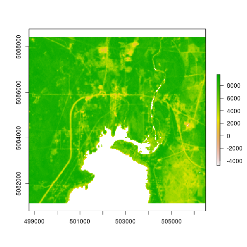

```r
# Visualize one of the layers produced
list <- list.files(dirout, pattern=glob2rx('*.grd'), full.names=TRUE)
plot(r <- raster(list[1]))
```

A few remarks about the above example:

- A mask (`mask=`) had to be selected; in that case `'fmask'`, which is one of the layers of the landsat archive file delivered by USGS/ESPA. For details about that mask and know which values to keep (`keep=`), you can visit [this page](http://code.google.com/p/cfmask/), or for general information on the layers provided in the archive, see the [product guide](http://landsat.usgs.gov/documents/cdr_sr_product_guide.pdf).
- The option `delete=` does not delete the original tarball/zip file, but instead the intermediary output, which is the layers uncompressed from the archive later used to compute the vegetation indices. This option is usefull in case you want to keep the data in their compressed form only, hence reducing disk space usage.
- No extent object (`e=`) was used in the example. However, it is advised to always use an extent to crop the layers produced. This way we ensure that all layers have exactly the same extent and can be used to create a multilayer object, which is the next step in the pre-processing chain. To obtain an extent, you may either use the interactive function `drawExtent()` to draw an extent manually, or use an existing spatial object (raster or vector).
- Masking and cropping are optional but highly recomended if you intend to perform subsequent time-series analysis with the layers produced.
- No output filename was required; that variable is automatically generated from the input file and the `vi` selected.
- The extension of the output is by default .grd. This is the native format of the raster package. This format has many advantages over more common GeoTiff or ENVI formats.
  - Original layer names are kept in multi-layer objects.
  - There is a possibility to add a z dimension to multilayer objects, useful for storing time information for instance.
  - Can be read and written without requiring the `rgdal` package (which is not always easy to install).

### Running `processLandsat` in batch mode

We saw above that the test data directory of the package contains 2 files (zip archives); we will generate from both of them vegetation index layers. This is not a great challenge, and could very well be achieved by running twice the same line, but in a real case you may very well have hundreds of input files and it will save you a lot of time and energy if you can process them all in one line.

```r
# Create a temporary directory to store the output files.
srdir <- dirout <- file.path(dirname(rasterTmpFile()), 'bfmspatial_2')
dir.create(dirout, showWarning=FALSE)

# Get the directory where the Landsat archives are stored
dir <- system.file('external', package='bfastSpatial')

# Run the batch line
processLandsatBatch(x=dir, pattern=glob2rx('*.zip'), outdir=dirout, srdir=srdir, delete=TRUE, vi='ndvi', mask='fmask', keep=0, overwrite=TRUE)
```

```
#> [[1]]
#> [1] TRUE TRUE
#>
#> [[2]]
#> [1] TRUE TRUE TRUE
```

```r
# Visualize one of the layers produced
list <- list.files(dirout, pattern=glob2rx('*.grd'), full.names=TRUE)
# plot(r <- raster(list[1]))
```

If you visualize the two layers produced, you'll notice that they look similar; this is simply because they in fact are the same image. Only the file name for one of the two images has been altered to make it look like it has been acquired at a different date. The reason behind this trick is that at the time we are writting this tutorial, USGS has only released **test data** of the new Landsat delivery format, and for only a few scenes and one date for each of these scenes.

### Creating a multi-temporal raster object

Once the vegetation index layers have been produced for several dates, they can be stacked, in order to create a multilayer raster object, with time dimention written in the file as well. The function to perform this operation on Landsat data is the `timeStack` function. By simply providing a list of file names or a directory containing the files, the function will create a multilayer object and directly parse through the file names to extract temporal information from them and write that information to the object created.

Make sure you have ran the previous code chunk before running the code below.

```r
# Make sure that the list object generated in the prvious code chunk
# contains 2 elements only
list
```

```
#> [1] "/tmp/R_raster_loicdtx/bfmspatial_2/ndvi.LE70230282011250.grd"
#> [2] "/tmp/R_raster_loicdtx/bfmspatial_2/ndvi.LE70230282015250.grd"
```

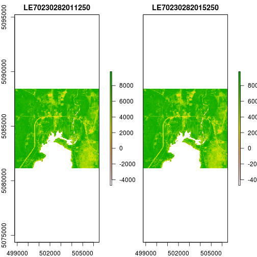

```r
# Create a new subdirectory in the temporary directory
dirout <- file.path(dirname(rasterTmpFile()), 'stack')
dir.create(dirout, showWarnings=FALSE)

# Generate a file name for the output stack
stackName <- file.path(dirout, 'stackTest.grd')

# Stack the layers
s <- timeStack(x=list, filename=stackName, datatype='INT2S', overwrite=TRUE)

# Visualize both layers (They are the same for the reason stated above)
plot(s)
```

About the example above:

- It is absolutely necessary for this function to work that the input layers have the same extent. Two Landsat scenes belonging to the same path/row, but acquired at different times often have slightly different extents. We therefore recomend to always use an extent object in `processLandsat` and `processLandsatBatch`, even when working with full scenes.
- Time information is automatically extracted from the layer names (using `getSceneInfo`) and written to the z dimention of the stack.
- We chose to write the output to the .grd format, which allows the time information to be stored as well as the original layer names.
- The `x=` argument can also simply be the directory containing the layers; in which case we recomend using `pattern=` as well in order to ensure that only the desired files are included.

### MODIS pre-processing

Note: Some of these functions require `rgdal` to be built with the HDF4 driver, which is not the case on most windows installations.

#### List of functions

The MODIS pre-processing category contains the following functions:

- `cleanMODIS()`: The basic function to extract a vegetation index or other layer from its hdf archive and clean it using its associated Quality Control (QC) or Quality Assessment (QA) layer.
- `cleanMODISbatch()`: A batcher for `cleanMODIS()` including support for parallel computing and the possibility to mosaic several tiles.
- `timeStackMODIS`: A function to create raster stacks of MODIS layers, with time written in the object properties.

## Data Inventory

A number of functions are available in the bfastSpatial package to help keep an inventory of data in a raster time series stack. These functions range from basic scene information (`getSceneinfo()`) to summary of pixel values per year in the time series (`annualSummary()`).

The following functions are included in the Data Inventory module:

1. `getSceneinfo()`
2. `countObs()`
3. `summaryBrick()`
4. `annualSummary()`
5. `getMODISinfo()`

### Basic Scene Information: `getSceneinfo()`

`getSceneinfo()` allows the user to list the information contained within a scene ID. Currently, only Landsat scene ID's are supported. For example, the scene ID ''LE71700552007309ASN00'' tells us that the scene is from the Landsat 7 ETM+ sensor ('LE7'), path-row 170-55 ('170055') and was acquired on the 309th day of the year 2007 ('2007309'). Calling `getSceneinfo('LE71700552007309ASN00')` will give a data.frame with one row showing all of this information:

```r
getSceneinfo('LE71700552007309ASN00')
```

```
#>                        sensor path row       date
#> LE71700552007309 ETM+ SLC-off  170  55 2007-11-05
```

When working with Landsat data, it is a good idea to assign and keep these sceneID's as layer names (see '?raster::names') so the relevant information is associated to each raster layer.

```r
# show scene info from tura layers
data(tura)

# show the layer names
names(tura)
s <- getSceneinfo(names(tura))
s
# add a column for years and plot # of scenes per year
s$year <- as.numeric(substr(s$date, 1, 4))
hist(s$year, breaks=c(1984:2014), main="p170r55: Scenes per Year",
     xlab="year", ylab="# of scenes")
```

[output not shown]

More examples can be found under `?getSceneinfo`. Many other functions in the bfastSpatial package rely on getSceneinfo to extract relevant scene information, such as acquisition dates to be passed to `bfmSpatial()` or `bfmPixel()`.

### Basic MODIS tile Information: `getMODISinfo()`

`getMODISinfo()` is the equivalent of `getSceneinfo()`, for MODIS type of data.

### Valid Observations: `countObs()`

The number of available observations in a raster time series can be calculated by using `countObs()`. This function "drills" through pixels of a time series and counts the number of pixels with a non-NA value. Optionally, any other value can be supplied as a substitute for NA (e.g. the number of non-zero values per pixel can also be queried).

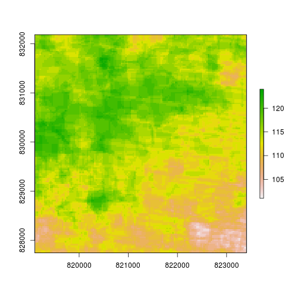

```r
data(tura)
obs <- countObs(tura)
plot(obs)
```

```r
summary(obs)
```

```
#>         layer
#> Min.      101
#> 1st Qu.   112
#> Median    114
#> 3rd Qu.   117
#> Max.      124
#> NA's        0
```

Values can also be expressed as a percentage if `as.perc` is set to `TRUE`.

```r
# valid observations
obs <- countObs(tura, as.perc=TRUE)
summary(obs)
# % NA per pixel
percNA <- 100 - countObs(tura, as.perc=TRUE)
plot(percNA, main="percent NA per pixel")
```

```r
summary(percNA)
```

### Summary Statistics: `summaryBrick()` and `annualSummary()`

In this section, we will calculate summary statistics for the Tura RasterBrick. First, general statistics for the entire brick can be calculated using `summaryBrick()`. In fact, `countObs()` is essentially a specific version of `summaryBrick`. `summaryBrick()` takes a RasterBrick as its first argument and a function as its second argument, and all others are optional arguments. Calculating the mean of each pixel is simple.

```r
meanVI <- summaryBrick(tura, fun=mean) # na.rm=FALSE by default
plot(meanVI)
```

[output not shown]

```r
meanVI <- summaryBrick(tura, fun=mean, na.rm=TRUE)
plot(meanVI)
```

`summaryBrick` can also take custom functions, provided these functinos are vectorized - in other words, they should be applicable to a vector extracted from a single pixel time series (for example, by taking a single cell number of the Tura RasterBrick: `x <- tura[500]`). Suppose we want to know how many observations per pixel exceed a certain threshold. First, we should define a function that can count the number of elements in a vector that exceed this threshold, and then pass this to `summaryBrick`. In this example, we will use 7000 as our threshold (remember that the values are scaled by 10000, so this corresponds to an NDVI of 0.7).

```r
# define a function that takes a vector as an argument
checkThresh <- function(x){
    # first, get rid of NA's
    x <- x[!is.na(x)]
    # if there still values left, count how many are above the threshold
    # otherwise, return a 0
    if(length(x) > 0){
        y <- length(x[x > 7000])
    } else {
        y <- 0
    }
    # return the value
    return(y)
}
# pass this functino to summaryBrick
customStat <- summaryBrick(tura, fun=checkThresh)
plot(customStat, main = "# of observations where NDVI > 0.7")
```

Note that in this case we handled NA values within our function, so there was no need to specify a value for `na.rm`. `summaryBrick` has some optional arguments that allow constraints according to dates and sensor (currently only for Landsat data). `sensor` takes a character vector of sensors to constrain the data, while `minDate` and `maxDate` allow a date range to be set to constrain the data. In the following example, we will calculate median pixel values using different date and sensor ranges.

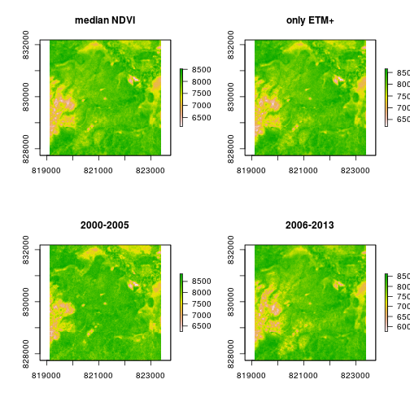

```r
# median values for all layers
medVI <- summaryBrick(tura, fun=median, na.rm=TRUE)
# only ETM+ layers
medVI_ETM <- summaryBrick(tura, fun=median, na.rm=TRUE, sensor="ETM+")
# all layers between 2000 and 2005 (inclusive)
medVI_00_05 <- summaryBrick(tura, fun=median, na.rm=TRUE, minDate="2000-01-01",
                            maxDate="2005-12-31")
# all layers after 2005
medVI_06_13 <- summaryBrick(tura, fun=median, na.rm=TRUE, minDate=c(2006, 1))
# plot and compare
op <- par(mfrow=c(2, 2))
plot(medVI, main = "median NDVI")
plot(medVI_ETM, main = "only ETM+")
plot(medVI_00_05, main = "2000-2005")
plot(medVI_06_13, main = "2006-2013")
```

```r
par(op)
```

`minDate` and `maxDate` can be supplied in one of two ways: (1) as a character or date object in the format `"%Y-%m-%d"` (eg. `"2013-01-31"`) or (2) as a numeric vector of length 2 representing the year and Julian day (e.g. `c(2013, 31)`).

Note that the Tura brick already has scene information included as layer names (see `names(tura)`). To run `annualSummary` on RasterBricks where no scene information is available, a dates vector **must** be supplied to be able to divide the layers into years. This vector is also required for `summaryBrick` when constraining the calculation by date using `minDate` and `maxDate`.

`annualSummary` works similarly to `summaryBrick`, but provides a statistic for each year of the time series. At this time, this function is only applicable to Landsat data, and the scene IDs must be supplied either as `names(x)` or as a separate character vector to `sceneID`. In this sample, we will again calculate median NDVI on all ETM+ data, but this time we are interested in seeing the **annual** median NDVI value.

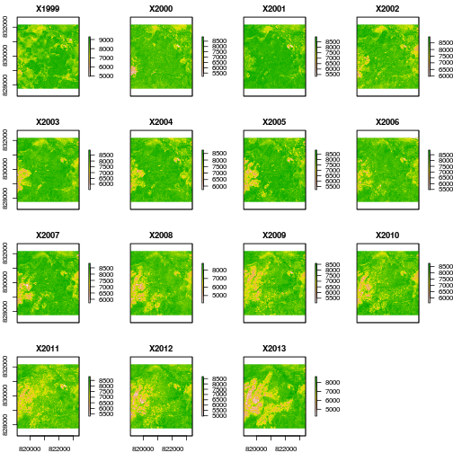

```r
annualMed <- annualSummary(tura, fun=median, sensor="ETM+", na.rm=TRUE)
plot(annualMed)
```

Both `summaryBrick()` and `annualSummary()` can pass additional arguments to `mc.calc()`, meaning that the result can be saved to file with a `filename` argument, and multiple cores can be used in the calculation with a `mc.cores` argument.

From the summary RasterBrick above, we can see that this is a very dynamic area, with some of the biggest forest changes occurring from 2009 until 2013. With the help of `bfastmonitor`, we will look at ways to quantify and map these changes at high temporal resolution.

## Spatial BFASTMonitor

### Working with pixels: `bfmPixel`

Working with `bfastmonitor` (BFM) can be intimidating at first, especially given the number of parameters that need to be set (or at least considered) before running the algorithm. It is important to understand these parameters, as not all raster time series are equal. Some time series may have frequent and large temporal gaps (as can be expected in some tropical forest), while others are temporally dense. These differences may call for slightly different approaches in implementing BFM.

`bfmPixel` is a function which queries individual pixels in a raster time series and runs bfm over that pixel's time series. To run `bfmPixel` in interactive mode, one of the layers of the time series needs to first be plotted.

```r
# load tura RasterBrick
data(tura)
# plot the 42nd layer
plot(tura, 42)
# run bfmPixel() in interactive mode with a monitoring period
# starting @ the 1st day in 2009
bfm <- bfmPixel(tura, start=c(2009, 1), interactive=TRUE)
# choose the pixel whose time series you want to see by clicking on the map you plotted a moment ago
```

Inspecting the output of this function, you will see that a list of length 2 has been returned. First, a list of class `bfastmonitor` is output under `$bfm`. Second, an integer indicating the cell number that has been clicked is output under `$cell`. The output is formatted this way so that if `bfmPixel` is run in interactive mode, a follow-up analysis can be done on that same cell without having to guess which cell was clicked before. In the above example, the cell number can be retrieved simply by typing `bfm$cell` in the console.

Let's run `bfmPixel` again, but this time indicating a specific cell number instead of using interactive mode. Note that by default `interactive=FALSE`, so there is no need to specify this if a value for `cell` is given.

```r
targcell <- 3492
bfm <- bfmPixel(tura, cell=targcell, start=c(2009, 1))
# inspect and plot the $bfm output
bfm$bfm
```

```
#>
#> BFAST monitoring
#>
#> 1. History period
#> Stable period selected: 1984(285)--2008(359)
#> Length (in years): 24.202740
#> Model fit:
#>   (Intercept)         trend    harmoncos1    harmoncos2    harmoncos3
#> 7577.91040699    0.09904891 -297.47431920   71.66340749   52.05171539
#>    harmonsin1    harmonsin2    harmonsin3
#> -393.96794178    5.38913710  -36.69532170
#> R-squared: 0.360894
#>
#>
#> 2. Monitoring period
#> Monitoring period assessed: 2009(1)--2013(101)
#> Length (in years): 4.273973
#> Break detected at: 2009(298)
```

```r
plot(bfm$bfm)
```

[output not shown]

Specifying a cell number gives the advantage of being able to test different parameters on the same pixel time series to see what impact these parameters have on the sensitivity of the algorithm. Note that a plot is immediately produced if `plot = TRUE`.

```r
# use a harmonic model only
bfm1 <- bfmPixel(tura, cell=targcell, start=c(2009, 1),
                 formula=response~harmon, plot=TRUE)
```

```r
# same, but with an order of 1
bfm2 <- bfmPixel(tura, cell=targcell, start=c(2009, 1),
                 formula=response~harmon, order=1, plot=TRUE)
```

```r
# only trend
bfm3 <- bfmPixel(tura, cell=targcell, start=c(2009, 1),
                 formula=response~trend, plot=TRUE)
```

Check out `?bfastmonitor` for more information on the parameters that are included in the method.

A number of additional options are provided in `bfmPixel`. Specifying a value for `monend` will trim the time series after that date (thus limiting the monitoring period to a given period). This simple modification can have an impact on the resulting change magnitude, which is computed as the median residual between the predicted and observed values within the monitoring period.

```r
# bfmPixel using a 1-year monitoring period
bfm4 <- bfmPixel(tura, cell=targcell, start=c(2009, 1),
                 monend=c(2010, 1), plot=TRUE)
```

Finally, for Landsat time series the analysis can be limited to data of a specific sensor. The `sensor` parameter currently accepts the following possible character values: * "ETM+" * "ETM+ SLC-on" * "ETM+ SLC-off" * "TM"

Note that in our previous runs of `bfmPixel`, there is what seems to be a bias between TM data from the 80's and 90's (which can be found throughout the scene). This has a large effect on our model, especially when a trend is included. A very quick way to avoid this bias is to include only data from the ETM+ sensor, which was launched in 1999.

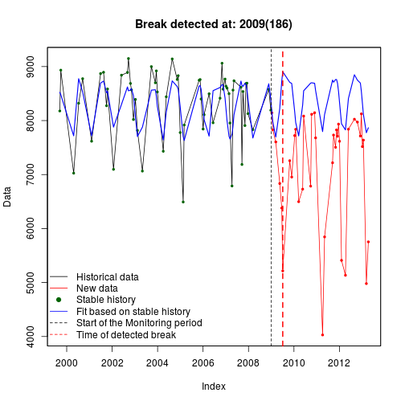

```r
# apply bfmPixel only on ETM+ data
bfm5 <- bfmPixel(tura, cell=targcell, start=c(2009, 1),
                 sensor="ETM+", plot=TRUE)
```

### Working with raster time series: `bfmSpatial`

Now that we have done some pixel-based testing, it is time to apply `bfastmonitor` over an entire raster time series. This will allow us to pinpoint the location and timing of changes in our study area. In the previous section, we saw that there was a large gap in the 1990's in the tura raster time series, and given the acceptable data density, we could just limit the analysis to ETM+ data. We also saw that a harmonic-trend model with an order of 1 seemed to be the most reasonable time series model for the tura dataset. We will pass these same arguments to `bfmSpatial`. At the same time, we will calculate how long the process takes by wrapping it in a `system.time` call.

```r
# run bfmSpatial over tura for a monitoring period of 2009 -
t1 <- system.time(
    bfm <- bfmSpatial(tura, start=c(2009, 1), order=1)
    )
# plot the result
plot(bfm)
```

[output not shown]

Luckily for us, tura is a very small RasterBrick, and processing is not incredibly time consuming. Realistically, analyses are done over significantly larger areas (possibly extending beyond a single scene), so running `bfmSpatial` on such large areas quickly becomes a very time-consuming task. To assist in this, multi-core support has been built into `bfmSpatial`, using the `parallel` package. Let's run the same line of code again, but this time specify a value for `mc.cores`, which will distribute the process over that many cpus. Again, we will wrap the code in a `system.time` call to test the speed of the processing.

```r
t2 <- system.time(
    bfm <- bfmSpatial(tura, start=c(2009, 1), order=1, mc.cores=2)
    )
# compare processing time with previous run
t1 - t2
```

## Post-Processing of BFM output

By default, three raster layers are output by `bfmSpatial`: 1. breakpoint timing - in decimal year format 2. change magnitude - the medial residual between expected and observed values in the monitoring period 3. error flag - possible values of 1 if an error has been encountered in a particular pixel, and NA where the algorithm was successful (or a mask had already been applied previously)

The `returnLayers` argument allows for additional outputs, including model parameters for each pixel, but we won't discuss those in this tutorial. See `?bfmSpatial` for more information.

The output of `bfmSpatial` is a simple rasterBrick. Individual layers can be extracted as with any rasterBrick object. As noted above, the first layer is the breakpoint timing:

```r
# extract change raster
change <- raster(bfm, 1)
```

The change raster gives breakpoint timing values in decimal years. A better way to map change timing from these results may be to show the month of change (the validity of this depends on the temporal density of there input time series). `changeMonth` is a convenient way to convert breakpoint values to change months. The result is one or more raster layers with integer values between 1 and 12, representing the months of the year. In cases where multiple years are represented in the change raster, these are split into raster layers representing one layer per year.

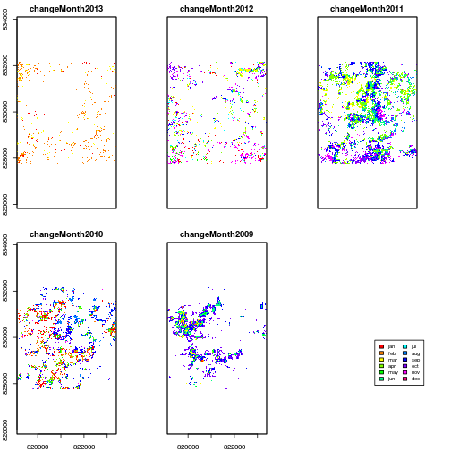

```r
months <- changeMonth(change)
# set up labels and colourmap for months
monthlabs <- c("jan", "feb", "mar", "apr", "may", "jun",
               "jul", "aug", "sep", "oct", "nov", "dec")
cols <- rainbow(12)
plot(months, col=cols, breaks=c(1:12), legend=FALSE)
# insert custom legend
legend("bottomright", legend=monthlabs, cex=0.5, fill=cols, ncol=2)
```

The second layer output by `bfmSpatial` is magnitude. Magnitude is computed as the median residual between expected and observed values throughout the **entire** monitoring period, meaning that all pixels are assigned a value regardless of whether or not a breakpoint has been detected.

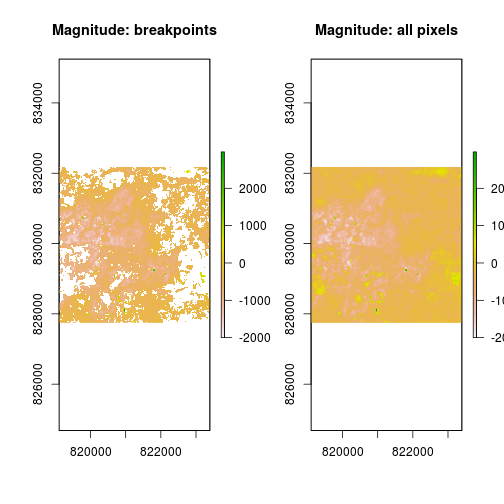

```r
# extract magn raster
magn <- raster(bfm, 2)
# make a version showing only breakpoing pixels
magn_bkp <- magn
magn_bkp[is.na(change)] <- NA
op <- par(mfrow=c(1, 2))
plot(magn_bkp, main="Magnitude: breakpoints")
plot(magn, main="Magnitude: all pixels")
```

```r
par(op)
```

Note that the magnitude values are in the same scale as the input data, which had been scaled by 10000. Scaling back can be done by simple raster algebra, or with the `raster::calc` function to enable writing to file.

```r
magn <- raster(bfm, 2) / 10000
```

The magnitude could be used to discriminate between actual deforestation and other factors that might give rise to breakpoints (such as noisy data). However, interpreting magnitude is complicated by the fact that follow-up dynamics can affect the magnitude value, since it is computed throughout the entire monitoring period. To circumvent this (not entirely), we will re-run `bfmSpatial` using a 1-year monitoring period, under the assumption that this monitoring window is too short for post-change dynamics to significantly affect the magnitude value. To do this, we will include the `monend` argument of `bfmSpatial`, which will limit the analysis to a specific time period. In this example, we will use a 2009-2010 monitoring period with all other parameters the same as above.

```r
bfm09 <- bfmSpatial(tura, start=c(2009, 1), monend=c(2010, 1), order=1)
# extract change
change09 <- raster(bfm09, 1)
# extract and rescale magnitude
magn09 <- raster(bfm09, 2) / 10000
# remove all non-breakpoints
magn09[is.na(change09)] <- NA
```

Suppose we know from field observations or other reference data that breakpoints with NDVI magnitudes of -0.05 are associated with high probability of detected actual deforestation. We can easily apply this threshold to our magnitude raster by replacing all values above -0.05 with `NA`.

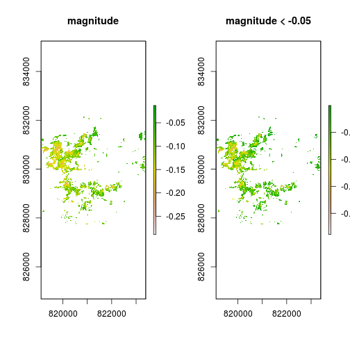

```r
# extract and rescale magnitude and apply a -500 threshold
magn09thresh <- magn09
magn09thresh[magn09 > -0.05] <- NA
# compare
op <- par(mfrow=c(1, 2))
plot(magn09, main="magnitude")
plot(magn09thresh, main="magnitude < -0.05")
```

```r
par(op)
```

A careful inspection of these results will show that applying the magnitude filter has changed the results somewhat, but since there isn't a great deal of noise in this example, the results were not dramatic. Another way we can clean up our results is to apply a minimum mapping unit. `areaSieve` does this by using detected pixel clumps (see `?raster::clump`) and removing all clumps with an area less than the given threshold (in square metres). For example, we can use the area of 2 pixels (1800 squre metres) as our cut-off, which would correspond to a single-pixel sieve.

```r
magn09_sieve <- areaSieve(magn09thresh, thresh=1800)
```

The default value for `thresh` is 5000, corresponding to a forest definition of 0.5 hectares.

```r
magn09_areasieve <- areaSieve(magn09thresh)
```

`areaSieve` passes additional arguments to `raster::clump`, which allows for considerations of direction when defining pixel neighbourhoods. `clump` adheres to the principle of 'queen's case' versus 'rook's case'. In the former, pixels in all directions (default: `directions = 8`) are considered when defining clumps, whereas in the latter case, only pixels directly adjacent (excluding diagonals) are considered (`directions = 4`).

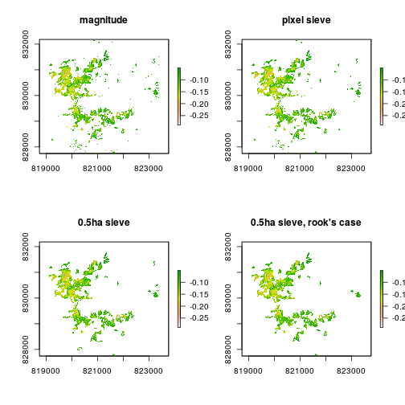

```r
magn09_as_rook <- areaSieve(magn09thresh, directions=4)
# compare all magn rasters
op <- par(mfrow=c(2, 2))
plot(magn09thresh, main="magnitude")
plot(magn09_sieve, main="pixel sieve")
plot(magn09_areasieve, main="0.5ha sieve")
plot(magn09_as_rook, main="0.5ha sieve, rook's case")
```

```r
par(op)
```

Once we have applied the desired filters and sieves to our bfm magnitude raster, we may want to calculate area statistics. This can be done with another simple function: `clumpSize`. This function is also based on the `raster::clumps` function and computes the size of each pixel clump and assigns that value back to each pixel in that clump. As in `areaSieve`, the queen's and rook's cases can also apply by adjusting the `directions` argument.

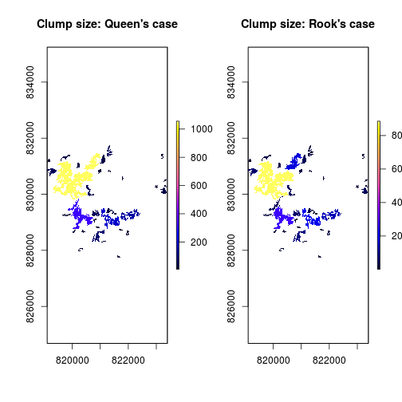

```r
changeSize_queen <- clumpSize(magn09_areasieve)
changeSize_rook <- clumpSize(magn09_areasieve, directions=4)
# compare
op <- par(mfrow=c(1, 2))
plot(changeSize_queen, col=bpy.colors(50), main="Clump size: Queen's case")
plot(changeSize_rook, col=bpy.colors(50), main="Clump size: Rook's case")
```

```r
par(op)
```

These clump sizes are in number of pixels, which might not be very useful when communicating our results. The `f` argument in `clumpSize` allows us to convert these to a useful area measure. In the case of Landsat, we know that each pixel covers 900m^2, and that one hectare equals 10000m^2. `clumpSize` can perform this conversion if a value for `f` is supplied.

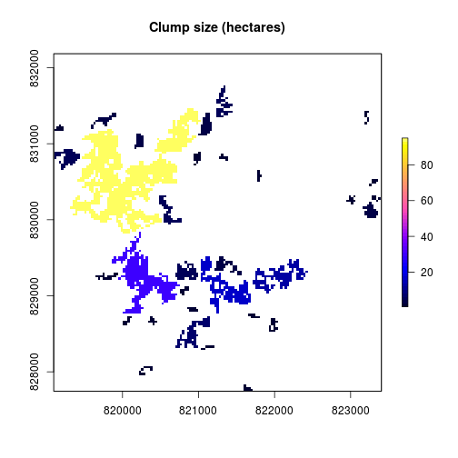

```r
changeSize <- clumpSize(magn09_areasieve, f=900/10000)
plot(changeSize, col=bpy.colors(50), main="Clump size (hectares)")
```

In order to calculate statistics of the changed area, it may be tempting to simply run `raster::summary`. But this function will produce misleading results, as *each pixel* has been assigned the value of its respective clump size (rather than representing each clump as a singular object, as would be the case with a SpatialPolygons object). To circumvent this, a `stats` argument is included in `clumpSize`, which outputs an additional summary table based on clumps rather than on individual pixels. If `stats=TRUE`, rather than outputting a single raster layer, `clumpSize` returns a list with 2 objects: (1) a raster layer as above; and (2) a summary table (matrix) showing mean, min, and all quartiles of the clump sizes.

```r
changeSize <- clumpSize(magn09_areasieve, f=900/10000, stats=TRUE)
print(changeSize$stats)
```

```
#>         clump size
#> Mean       6.26625
#> Min.       0.54000
#> 1st Qu.    0.72000
#> Median     1.21500
#> 3rd Qu.    3.73500
#> Max.      95.04000
```

We can say that based on our analysis, the average size of change units in Tura in 2009 is estimated to be 6.3 hectares. In this case, the minimum is not suprising, since we had already applied an area sieve using 0.5 hectares as our threshold.

# References

Styled with knitrBootstrap

DeVries, Ben, Jan Verbesselt, Lammert Kooistra, and Martin Herold. 2015. “Robust Monitoring of Small-Scale Forest Disturbances in a Tropical Montane Forest Using Landsat Time Series.” *Remote Sensing of Environment* 161: 107–121. doi:10.1016/j.rse.2015.02.012.

Dutrieux, Loïc Paul, Jan Verbesselt, Lammert Kooistra, and Martin Herold. 2015. “Monitoring Forest Cover Loss Using Multiple Data Streams, a Case Study of a Tropical Dry Forest in Bolivia.” *ISPRS Journal of Photogrammetry and Remote Sensing* In press. doi:10.1016/j.isprsjprs.2015.03.015.

Verbesselt, J., R. Hyndman, G. Newnham, and D. Culvenor. 2010. “Detecting Trend and Seasonal Changes in Satellite Image Time Series.” *Remote Sensing of Environment* 114 (1): 106–115. doi:10.1016/j.rse.2009.08.014.

Verbesselt, J., A. Zeileis, and M. Herold. 2012. “Near Real-Time Disturbance Detection Using Satellite Image Time Series.” *Remote Sensing of Environment* 123: 98–108. doi:10.1016/j.rse.2012.02.022.